# Import and the Pipe

POLS 6394 · Week 3 · Thursday, September 10

## Today

- Import CSV and Stata data
- Check what R did while importing a file
- Compare base R with tidyverse code
- Use both R pipe operators
- Work with Boolean values and build categories with `case_when()`
- Answer questions from a new dataset

## RStudio keyboard shortcuts

| Action | Mac | Windows |
| --- | --- | --- |
| Save | **Cmd+S** | **Ctrl+S** |
| Run the current line or selection | **Cmd+Return** | **Ctrl+Enter** |
| Insert `<-` | **Option+−** | **Alt+−** |
| Insert a pipe | **Cmd+Shift+M** | **Ctrl+Shift+M** |
| Insert an R chunk | **Cmd+Option+I** | **Ctrl+Alt+I** |
| Render | **Cmd+Shift+K** | **Ctrl+Shift+K** |

If the pipe shortcut inserts `%>%`, enable **Use native pipe operator** in RStudio’s Code options.

# Importing Data

## The tidyverse

The **tidyverse** is a collection of R packages with a shared approach to working with data.

- Tidy tables: one observation per row, one variable per column.
- Named operations connect importing, transforming, and presenting data.
- We’ll mainly use tidyverse code, with occasional **base R** examples.

Base R comes with R itself. Tidyverse packages add to it.

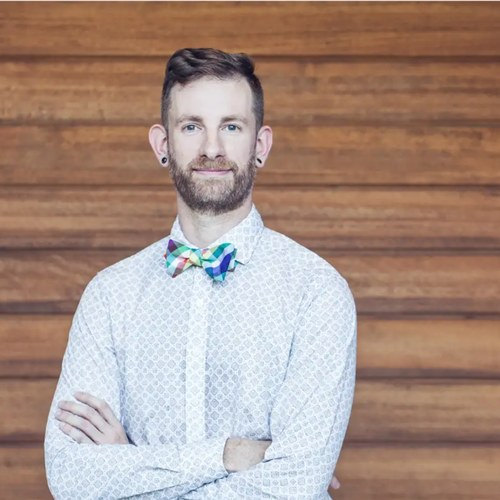

Hadley Wickham

**Hadley Wickham**  
Coauthor of dplyr

## `read_csv()`: the default CSV reader

A CSV is a plain-text table with columns separated by commas. `read_csv()` from `readr` reads one into R.

```r
library(tidyverse)

policy <- read_csv(
  "Data/state_policy/cspp_states.csv",
  show_col_types = FALSE
)
```

`<-` assigns the imported table to `policy`. The path starts inside this project. `show_col_types = FALSE` hides a report we’ll examine in a moment.

Insert `<-`: **Mac Option+− · Windows Alt+−** (minus key). Run the selected code: **Mac Cmd+Return · Windows Ctrl+Enter**.

## New lines and indentation

```r
policy <- read_csv(
  "Data/state_policy/cspp_states.csv",
  show_col_types = FALSE
)
```

- Short calls can stay on one line. Split longer calls after `(`, with one argument per line.
- Indent continued lines **two spaces**, not literal tabs. Align the closing `)` with the start of the call.
- Keep commas between arguments. A new line doesn’t replace a comma.
- Put spaces around `<-` and `=`. Use a blank line between separate steps.

The open `(` tells R the call continues. Indentation makes it easier for us to read.

Reformat selected R code: **Mac Cmd+Shift+A · Windows Ctrl+Shift+A**.

## Vectors

A **vector** is an ordered collection of values. The columns we’ve been working with are vectors.

```r
scores <- c(0.2, -0.1, NA)
scores
```

```
[1]  0.2 -0.1   NA
```

- `c()` combines values; commas separate them.
- `<-` saves this three-element vector as `scores`.
- `NA` marks a missing value. It still occupies a position.
- The printed `[1]` marks the first position, not another value.
- R’s functions often operate on a whole vector at once. This is usually simpler and faster than processing its values one at a time.

These simple vectors hold one type of value: numbers, text, or logical values.

## Data frames and tibbles

A **data frame** is a rectangular table: named columns of equal length. Each column is a vector; different columns can hold different types.

A **tibble** is a kind of data frame used by the tidyverse. `read_csv()` returns one.

| Behavior | Base data frame | Tibble |
| --- | --- | --- |
| Printing | Can fill the Console | Compact preview with column types |
| Row labels | Can store special row names | Keep identifiers in a regular column |

Most R tools accept either. `as_tibble(x)` converts to a tibble; `as.data.frame(x)` converts to a base data frame. Here `x` means your table.

In base R, `policy$year` identifies both the data frame and its `year` column. Inside a dplyr verb, the data frame has already been supplied, so we can refer to `year` by itself.

## Inspecting a tibble

```r
glimpse(policy)
```

```
Rows: 2,205
Columns: 25
$ st                 <chr> "AL", "AL", "AL", "AL", "AL", "AL", "AL", "AL", "AL…
$ state              <chr> "Alabama", "Alabama", "Alabama", "Alabama", "Alabam…
$ region.name        <chr> "south", "south", "south", "south", "south", "south…
$ year               <dbl> 1976, 1977, 1978, 1979, 1980, 1981, 1982, 1983, 198…
$ pid                <dbl> 0.23, 0.25, 0.44, 0.38, 0.38, 0.25, 0.29, 0.29, 0.1…
$ ideo               <dbl> -0.21, -0.08, -0.18, -0.21, -0.23, -0.31, -0.26, -0…
$ statemin           <dbl> NA, NA, NA, NA, 3.10, 3.35, 3.35, 3.35, 3.35, 3.35,…
$ pollib_median      <dbl> -1.4, -1.4, -1.5, -1.5, -1.7, -1.7, -1.8, -1.8, -1.…
$ region             <dbl> 1, 1, 1, 1, 1, 1, 1, 1, 1, 1, 1, 1, 1, 1, 1, 1, 1, …
$ polconserv         <dbl> 1.4, 1.4, 1.5, 1.5, 1.7, 1.7, 1.8, 1.8, 1.8, 1.8, 1…
$ democrat           <dbl> NA, NA, NA, NA, NA, NA, NA, NA, NA, 43.17758, 44.09…
$ republican         <dbl> NA, NA, NA, NA, NA, NA, NA, NA, NA, 26.86652, 26.53…
$ liberal            <dbl> NA, NA, NA, NA, NA, NA, NA, NA, NA, 21.133596, 17.7…
$ conservative       <dbl> NA, NA, NA, NA, NA, NA, NA, NA, NA, 28.44691, 33.38…
$ tobratio           <dbl> NA, NA, NA, NA, NA, NA, NA, NA, NA, NA, NA, NA, NA,…
$ healthratio        <dbl> NA, NA, NA, NA, NA, NA, NA, NA, NA, NA, NA, NA, NA,…
$ tobaccolobby2      <dbl> NA, NA, NA, NA, NA, NA, NA, NA, NA, NA, NA, NA, NA,…
$ healthlobby2       <dbl> NA, NA, NA, NA, NA, NA, NA, NA, NA, NA, NA, NA, NA,…
$ pctsmoker          <dbl> NA, NA, NA, NA, NA, NA, NA, NA, NA, NA, NA, NA, NA,…
$ propneighban       <dbl> NA, NA, NA, NA, NA, NA, NA, NA, NA, NA, NA, NA, NA,…
$ pct_covered_state2 <dbl> NA, NA, NA, NA, NA, NA, NA, NA, NA, NA, NA, NA, NA,…
$ restban_inn        <dbl> NA, NA, NA, NA, NA, NA, NA, NA, NA, NA, NA, NA, NA,…
$ tobacco            <dbl> NA, NA, NA, NA, NA, NA, NA, NA, NA, NA, NA, NA, NA,…
$ smr                <dbl> NA, NA, NA, NA, NA, NA, NA, NA, NA, NA, NA, NA, NA,…
$ prior              <dbl> NA, NA, NA, NA, NA, NA, NA, NA, NA, NA, NA, NA, NA,…
```

`glimpse()` lists the dimensions, column names, types, and a few values from every column. `<chr>` means text; `<dbl>` means numbers stored as doubles.

## Read the table before changing it

- **Observational unit:** one state in one year
- **Identifiers:** `st` and `year` together locate a row
- **Measurements:** `pid`, `ideo`, and `statemin` describe that state-year
- Storage type doesn’t determine meaning. A numeric case number still identifies a row.

Write down the unit before calculating anything. It determines what your results describe.

## Import functions

| Source | Package | Function |
| --- | --- | --- |
| CSV | readr | `read_csv()` |
| Excel | readxl | `read_excel()` |
| Stata / SPSS | haven | `read_dta()` / `read_sav()` |
| Google Sheets | googlesheets4 | `read_sheet()` |
| One saved R object | base R | `readRDS()` |

You may see `readr::read_csv()`: `::` selects a function from a specific package without loading it with `library()`. We’ve loaded readr through `library(tidyverse)`, so `read_csv()` is enough.

After importing, use `glimpse()` to check the table.

## Stata data in R

```r
library(haven)

states_stata <- read_dta(
  "Data/state_policy/state_data_1993_2016.dta"
)
glimpse(states_stata)
```

`library(haven)` loads the Stata reader and its label-handling functions.

`read_dta()` reads Stata’s file format into a tibble. Use the same inspection and dplyr verbs as with a CSV.

Run `glimpse()` and inspect the column names and types in your Console.

## RDS and `.RData`

```r
dir.create("Processed/03b", recursive = TRUE, showWarnings = FALSE)
saveRDS(policy, "Processed/03b/policy.rds")
policy_again <- readRDS("Processed/03b/policy.rds")
save(policy, file = "Processed/03b/policy.RData")
load("Processed/03b/policy.RData")
```

`dir.create()` makes this lesson’s subfolder. `recursive = TRUE` also creates the parent `Processed` folder if needed; `showWarnings = FALSE` suppresses the warning if it exists.

`saveRDS()` writes one object; `readRDS()` returns it for assignment.

`save()` stores named objects; `load()` restores those names. An `.RData` file may be a deliberate bundle, not a whole workspace. It’s fine to use, but `load()` doesn’t return a table for a pipeline.

## Parsing during import

R must decide whether each column contains numbers, dates, text, or something else. Here the percent sign makes `turnout` text.

```r
turnout_raw <- read_csv(
  "Data/import/turnout-messy.csv",
  na = "N/A"
)

glimpse(turnout_raw)
```

```
Rows: 4
Columns: 2
$ state   <chr> "Texas", "California", "Florida", "New York"
$ turnout <chr> "53.4%", "59.2%", NA, "58.4%"
```

`na = "N/A"` identifies the file’s missing-value code. If `read_csv()` reports parsing failures, inspect them with `problems()`.

# The Pipe

## Why use a pipe?

A pipe starts with the table and passes it to a function. Here both forms display the first three rows.

```r
# Function call
head(policy, 3)

# Piped
policy |>
  head(3)
```

`|>` passes the result on its left into the first argument of the function on its right.

Put each pipeline step on a new line, indented two spaces, with `|>` at the end of the preceding line.

## Two pipes you will encounter

```r
# Base R pipe, built into R 4.1 and later
policy |>
  head(3)

# magrittr pipe, loaded with the tidyverse
policy %>%
  head(3)
```

Both pipelines give the same result. Older code often uses `%>%`; we’ll use `|>`.

Insert a pipe: **Mac Cmd+Shift+M · Windows Ctrl+Shift+M**. If this inserts `%>%`, enable **Use native pipe operator** in RStudio’s Code options to get `|>`.

# Logic and the Verbs

## Boolean values

A comparison returns a **Boolean**, also called a logical value: `TRUE`, `FALSE`, or `NA` when R can’t tell.

| Operator | Meaning | Example |
| --- | --- | --- |
| `==`, `!=` | equal, not equal | `year == 2010` |
| `>`, `>=`, `<`, `<=` | numeric comparison | `pid > 0` |
| `&`, `\\|` | and, or | `year == 2010 & pid > 0` |
| `!` | not | `!is.na(pid)` |
| `%in%` | matches any value in a vector | `year %in% c(2000, 2010)` |

One `=` names an argument or assigns inside `mutate()`. Two `==` test equality.

`is.na(pid)` tests whether `pid` is missing. The `!` reverses the result, so `!is.na(pid)` means that `pid` is present.

## `filter()`: keep rows

`filter()` evaluates a comparison for every row and keeps the rows where the result is `TRUE`.

```r
policy |>
  filter(year == 2010 & pid > 0) |>
  head(6)
```

```
# A tibble: 6 × 25
  st    state        region.name  year   pid  ideo statemin pollib_median region
  <chr> <chr>        <chr>       <dbl> <dbl> <dbl>    <dbl>         <dbl>  <dbl>
1 AR    Arkansas     south        2010  0.07 -0.31     6.25          -1.7      1
2 CA    California   west         2010  0.11 -0.05     8              2.4      2
3 CT    Connecticut  northeast    2010  0.11 -0.06     8.25           1.9      4
4 DC    District of… south        2010  0.47  0.33     8.25          NA        1
5 DE    Delaware     south        2010  0.04 -0.28     7.25           0.7      1
6 FL    Florida      south        2010  0.01 -0.22     7.25          -0.8      1
# ℹ 16 more variables: polconserv <dbl>, democrat <dbl>, republican <dbl>,
#   liberal <dbl>, conservative <dbl>, tobratio <dbl>, healthratio <dbl>,
#   tobaccolobby2 <dbl>, healthlobby2 <dbl>, pctsmoker <dbl>,
#   propneighban <dbl>, pct_covered_state2 <dbl>, restban_inn <dbl>,
#   tobacco <dbl>, smr <dbl>, prior <dbl>
```

`&` requires both comparisons to be true. Use `|` when either comparison may be true, and `%in%` when several exact values are acceptable.

## Missing comparisons

```r
scores > 0
```

```
[1]  TRUE FALSE    NA
```

```r
!is.na(scores)
```

```
[1]  TRUE  TRUE FALSE
```

The first line compares each element of `scores` with zero and returns a logical vector of the same length: `TRUE`, `FALSE`, `NA`.

`is.na()` identifies missing values; `!` reverses the result. `filter()` keeps only `TRUE`, so a missing comparison drops that row too.

## Combining conditions

```r
policy |>
  filter(year == 2010 & (st == "TX" | st == "CA"))
```

```
# A tibble: 2 × 25
  st    state      region.name  year   pid  ideo statemin pollib_median region
  <chr> <chr>      <chr>       <dbl> <dbl> <dbl>    <dbl>         <dbl>  <dbl>
1 CA    California west         2010  0.11 -0.05     8              2.4      2
2 TX    Texas      south        2010 -0.14 -0.36     7.25          -1        1
# ℹ 16 more variables: polconserv <dbl>, democrat <dbl>, republican <dbl>,
#   liberal <dbl>, conservative <dbl>, tobratio <dbl>, healthratio <dbl>,
#   tobaccolobby2 <dbl>, healthlobby2 <dbl>, pctsmoker <dbl>,
#   propneighban <dbl>, pct_covered_state2 <dbl>, restban_inn <dbl>,
#   tobacco <dbl>, smr <dbl>, prior <dbl>
```

`&` requires both sides. `|` accepts either side. Parentheses keep the two state choices together.

Change `"CA"` to another state abbreviation and run it once. `st %in% c("TX", "CA")` is a shorter way to express the original state choices.

## Your Turn: filter

*~4 minutes.*

Keep 2010 observations from either the South or the West (`"south"` and `"west"` in `region.name`). Write the condition using `&`, `|`, and parentheses.

```r
policy |>
  filter(___)
```

Check that every row meets both requirements: the year and one of the two regions. Could you use `%in%` instead?

## `select()` and `arrange()`

`select()` keeps columns. `arrange()` orders rows.

```r
policy |>
  filter(year == 2010) |>
  select(state, pollib_median) |>
  arrange(desc(pollib_median))
```

```
# A tibble: 49 × 2
   state         pollib_median
   <chr>                 <dbl>
 1 California              2.4
 2 New Jersey              2.4
 3 New York                2.3
 4 Massachusetts           2
 5 Connecticut             1.9
 6 Rhode Island            1.8
 7 Vermont                 1.8
 8 Maryland                1.7
 9 Oregon                  1.5
10 Maine                   1.4
# ℹ 39 more rows
```

`arrange()` sorts from low to high. `desc()` reverses the order.

## Your Turn: select and arrange

*~4 minutes.*

For those same regions in 2010, show `state` and `statemin` (recorded state minimum wage), highest first. Then add a condition keeping only wages of at least $8.

```r
policy |>
  filter(___) |>
  select(state, ___) |>
  arrange(___)
```

Which entries remain? The data include DC as well as states.

## Base R and tidyverse

The same row-and-column operation can be written either way.

```r
base_result <- policy[
  policy$year == 2010,
  c("state", "pid")
]

tidy_result <- policy |>
  filter(year == 2010) |>
  select(state, pid)
```

Inside base R’s brackets, the row instruction comes before the comma and the column instruction comes after it. `$year` extracts the `year` column. We use dplyr because the named verbs remain readable as pipelines grow.

## `mutate()`: calculations and comparisons

`mutate()` creates or replaces columns. The expression on the right can calculate a number or run a comparison.

```r
policy |>
  filter(year == 2010) |>
  mutate(
    min_wage_hike = statemin - 7.25,
    min_wage_hike_cents = min_wage_hike * 100,
    moredem = pid > 0
  ) |>
  select(state, pid, moredem, min_wage_hike, min_wage_hike_cents) |>
  head(6)
```

```
# A tibble: 6 × 5
  state         pid moredem min_wage_hike min_wage_hike_cents
  <chr>       <dbl> <lgl>           <dbl>               <dbl>
1 Alabama     -0.16 FALSE         0                     0
2 Arkansas     0.07 TRUE         -1                  -100
3 Arizona     -0.01 FALSE         0                     0
4 California   0.11 TRUE          0.75                 75
5 Colorado    -0.1  FALSE        -0.01000              -1.000
6 Connecticut  0.11 TRUE          1                   100
```

`mutate()` works from top to bottom. A later line can use a column created above it. Here `min_wage_hike_cents` uses `min_wage_hike`, and `moredem` is Boolean.

## Your Turn: related columns

*~4 minutes.*

For 2010, calculate the state minimum-wage difference from $7.25 in dollars and cents. Then create a Boolean showing whether the state minimum exceeds $7.25.

```r
policy |>
  filter(year == 2010) |>
  mutate(
    wage_gap = statemin - 7.25,
    wage_gap_cents = ___ * 100,
    above_federal = ___ > 7.25
  ) |>
  count(above_federal)
```

Which row counts states with missing minimum-wage data?

## More than two categories with `case_when()`

```r
policy |>
  filter(year == 2010) |>
  mutate(
    partisan_group = case_when(
      is.na(pid) ~ "Missing",
      pid > 0.20 ~ "Democratic",
      pid > 0 ~ "Leans Democratic",
      .default = "Republican or tied"
    )
  ) |>
  select(state, pid, partisan_group) |>
  head(6)
```

```
# A tibble: 6 × 3
  state         pid partisan_group
  <chr>       <dbl> <chr>
1 Alabama     -0.16 Republican or tied
2 Arkansas     0.07 Leans Democratic
3 Arizona     -0.01 Republican or tied
4 California   0.11 Leans Democratic
5 Colorado    -0.1  Republican or tied
6 Connecticut  0.11 Leans Democratic
```

`case_when()` checks from top to bottom and uses the first true condition. `~` separates each condition from its result. `.default` handles everything that has not matched.

# Combining Transformations

## A multi-step pipeline

```r
policy |>
  filter(year %in% c(1990, 2010)) |>
  mutate(moredem = pid > 0) |>
  select(state, year, pid, moredem, pollib_median) |>
  arrange(year, desc(pollib_median)) |>
  head(6)
```

```
# A tibble: 6 × 5
  state          year   pid moredem pollib_median
  <chr>         <dbl> <dbl> <lgl>           <dbl>
1 California     1990 -0.03 FALSE             1.9
2 New Jersey     1990  0    FALSE             1.7
3 Massachusetts  1990  0.11 TRUE              1.6
4 New York       1990  0.08 TRUE              1.6
5 Rhode Island   1990  0.05 TRUE              1.6
6 Connecticut    1990 -0.06 FALSE             1.2
```

The pipeline keeps two years, creates a Boolean column, selects five columns, and sorts the result. Each line changes one part of the table.

`c(1990, 2010)` combines the two years into one vector. `%in%` tests whether each value of `year` appears in that vector.

# Lab

## Lab: Chicago Airbnb listings

*~20 minutes.*

```r
airbnb <- read_csv("Data/airbnb/airbnb.csv", show_col_types = FALSE)
glimpse(airbnb)
```

```
Rows: 1,561
Columns: 13
$ rownames      <dbl> 1, 2, 3, 4, 5, 6, 7, 8, 9, 10, 11, 12, 13, 14, 15, 16, 1…
$ price         <dbl> 85, 35, 175, 75, 160, 60, 39, 65, 47, 100, 150, 38, 87, …
$ rating        <dbl> 5.0, 5.0, 4.5, 5.0, 5.0, 5.0, 5.0, 5.0, 4.5, 4.5, 4.5, 5…
$ reviews       <dbl> 6, 8, 7, 52, 3, 5, 8, 25, 7, 24, 8, 3, 10, 15, 3, 6, 5, …
$ room_type     <chr> "Private room", "Private room", "Entire home/apt", "Priv…
$ accommodates  <dbl> 2, 1, 4, 2, 6, 1, 2, 2, 2, 6, 6, 1, 4, 3, 4, 6, 2, 4, 4,…
$ bedrooms      <dbl> 1, 1, 2, 1, 2, 1, 1, 1, 1, 2, 2, 1, 1, 1, 2, 3, 1, 0, 1,…
$ minimum_stay  <dbl> 1, 1, 2, 1, 1, 1, 3, 2, 1, NA, 5, 10, 2, 1, 2, 2, 1, NA,…
$ neighborhood  <chr> "Albany Park", "Albany Park", "Albany Park", "Albany Par…
$ district      <chr> "Far North", "Far North", "Far North", "Far North", "Far…
$ walk_score    <dbl> 87, 87, 87, 87, 87, 87, 87, 87, 87, 87, 87, 87, 87, 87, …
$ transit_score <dbl> 62, 62, 62, 62, 62, 62, 62, 62, 62, 62, 62, 62, 62, 62, …
$ bike_score    <dbl> 68, 68, 68, 68, 68, 68, 68, 68, 68, 68, 68, 68, 68, 68, …
```

Four guests, two nights, at most $600 total. Find an entire-home listing with a rating of at least 4.5.

Use the historical nightly prices, excluding fees and taxes.

## Lab tasks

1. Fill the four booking conditions in the screen.
2. Calculate total cost and each guest’s share. Show five affordable options.
3. Use a Boolean for access and `case_when()` for price groups.
4. Write a pipeline for the $450 budget and recommend a listing.

Insert an R chunk: **Mac Cmd+Option+I · Windows Ctrl+Alt+I**.

Keep enough columns to verify your choices. The workbook supplies less code as you go.

## Finalize 03b

1. Save and render the workbook as far as you got. Render: **Mac Cmd+Shift+K · Windows Ctrl+Shift+K**.
2. Keep unfinished chunks at `eval: false` so they don’t run.
3. Inspect changes, commit with a specific message, and push.
4. Confirm the commit on GitHub.

If rendering fails, record the error and ask us. Still commit and push the saved QMD before leaving.

## Before Next Class

- **Read:** ModernDive §§1.4 and 3.1–3.4. Use R4DS chapters 3–4 as reference.
- **Optional practice:** Heiss’s [tibbles](https://r-primers.andrewheiss.com/transform-data/01-tibbles/), [isolating](https://r-primers.andrewheiss.com/transform-data/02-isolating/), and [deriving](https://r-primers.andrewheiss.com/transform-data/03-deriving/) primers
- **Next class:** grouped summaries, counts, missing values, and cleaning names

# If Time Remains

## Extension 1, step 1: Google Sheets

*~12–15 minutes.*

We’ll create our own spreadsheet and read it back into R.

```r
library(googlesheets4)
gs4_auth()
```

`library()` loads the package. `gs4_auth()` asks you to choose a Google account and grant access. Follow the browser and Console prompts.

We sign in because we’re creating a spreadsheet in our own account.

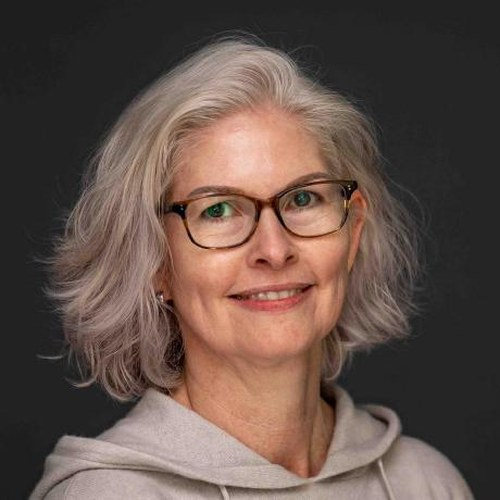

Jenny Bryan

**Jenny Bryan**  
Author of googlesheets4

## Extension 1, step 2: Create a spreadsheet

`mtcars` is built into R: 32 cars with fuel economy and other measurements. Its car names are row names, so make them a column first.

```r
cars <- rownames_to_column(mtcars, var = "model")
```

```r
cars_sheet <- gs4_create(
  "POLS 6394 - mtcars",
  sheets = list(Cars = cars)
)
```

`gs4_create()` creates the Google spreadsheet. `list(Cars = cars)` supplies one tab named **Cars** containing our table. `cars_sheet` stores its identifier. Run this creation chunk once; rerunning it creates another spreadsheet.

## Extension 1, step 3: Open it on the web

```r
gs4_browse(cars_sheet)
```

`gs4_browse()` opens the spreadsheet in your browser.

- Find the **Cars** tab and the **model** column.
- Change the first car’s `mpg` value to 99, an obvious practice edit.
- Wait for Google Sheets to save the change.
- Copy the spreadsheet URL into your workbook so you can return to it.

The spreadsheet belongs to your signed-in Google account. You don’t need to make it public.

## Extension 1, step 4: Read it back into R

```r
cars_back <- read_sheet(cars_sheet, sheet = "Cars")
head(cars_back, 3)
```

`read_sheet()` downloads the tab into a new R object. `sheet = "Cars"` chooses the tab. `head(..., 3)` displays the first three rows.

Confirm that the edited `mpg` value appears. Restore the original value in Google Sheets and rerun this read chunk. The original `cars` object in R still contains that value.

After restarting R, use the quoted spreadsheet URL in place of `cars_sheet`; you don’t need to create the spreadsheet again.

## Extension 1, step 5: Save a local CSV copy

```r
write_csv(cars_back, "Data/import/mtcars-from-sheets.csv")
```

`write_csv()` writes the downloaded table to the named file inside this project. Open the CSV from RStudio’s Files pane.

You can also download it through Google Sheets: **File → Download → Comma-separated values (.csv)**. That saves the current tab through your browser, usually into Downloads.

Keep the Google calls marked `eval: false`: run them manually during class so rendering won’t trigger authentication or create another spreadsheet.

## Extension 2: Stata value labels

A labelled column can store numbers such as 1 and 2 alongside labels such as “Democrat” and “Republican.”

```r
party_codes <- labelled(
  c(1, 2, 1),
  labels = c(Democrat = 1, Republican = 2)
)
party_codes
```

```
<labelled<double>[3]>
[1] 1 2 1

Labels:
 value      label
     1   Democrat
     2 Republican
```

```r
as_factor(party_codes)
```

```
[1] Democrat   Republican Democrat
Levels: Democrat Republican
```

This small example constructs labels for demonstration. `as_factor()` turns value labels into categories. Keep numeric measurements numeric.

## Extension 3: Repair a text column

```r
turnout <- turnout_raw |>
  mutate(turnout = parse_number(turnout))

glimpse(turnout)
```

```
Rows: 4
Columns: 2
$ state   <chr> "Texas", "California", "Florida", "New York"
$ turnout <dbl> 53.4, 59.2, NA, 58.4
```

`parse_number()` keeps the numeric part of values such as `"53.4%"`. The result is measured in percentage points. Divide by 100 only when a later calculation needs proportions from 0 to 1.

## Extension 4: Repair an import

*~8–10 minutes.*

This teaching file uses `"Missing"` for unavailable turnout, percent signs for turnout, and dollar signs for spending.

```r
election_raw <- read_csv(
  "Data/import/election-repair.csv",
  na = "Missing",
  show_col_types = FALSE
)
election_raw
```

```
# A tibble: 4 × 4
  state      turnout spending   registered
  <chr>      <chr>   <chr>           <dbl>
1 Texas      53.4%   $1,200,000     100000
2 California 59.2%   $1,800,000     120000
3 Florida    <NA>    $900,000       100000
4 New York   58.4%   $1,000,000      80000
```

Inspect the types. Repair `turnout` and `spending`, then find the state with the highest spending per registered voter.

## Extension 4: Check the repaired values

Write a pipeline that parses the two text columns, calculates `spending_per_voter`, and sorts it highest first. Keep the state and the columns needed to check the calculation.

Explain why the row with missing turnout can still have a spending estimate. Does `parse_number()` convert a percentage to a proportion, or just remove the percent sign?

## Extension 5: Repair a screening rule

*~8–10 minutes.*

A survey accepts adults aged 18 or older who choose either online or phone participation. This screen lets an ineligible person through.

```r
applicants <- tibble(
  id = c("A", "B", "C", "D", "E"),
  age = c(17, 25, 40, 16, 30),
  mode = c("phone", "online", "mail", "online", "phone")
)
applicants |>
  filter(age >= 18 & mode == "online" | mode == "phone")
```

```
# A tibble: 3 × 3
  id      age mode
  <chr> <dbl> <chr>
1 A        17 phone
2 B        25 online
3 E        30 phone
```

`tibble()` builds the table from named columns; each `c()` supplies that column’s values. Identify the incorrect inclusion before editing the condition.

## Extension 5: Check the corrected screen

- Add parentheses to repair the rule. Keep both participation modes.
- Check every returned row against the written requirements.
- Rewrite the condition with `%in%`. Does it return the same IDs?
- Explain why sorting the original result would not fix it.

These extensions are optional.